# Portfolio Task 1: Time Series Forecasting with the Decomposition Technique

## Introduction

Carry out a study on behalf of a business analytics specialised consultancy on a subsample of monthly data. Provided is a common starter time series data set which shows the number of airline passengers there were per month in the United States in the `1950s`.

## Recommendations

- Increase Capacity During Peak Months `July` and `August`: The Airline should consider increasing flight capacity during these months. This could involve adding more flights or larger aircraft to meet the surge in demand.
- Since `November` shows the lowest demand, airlines could focus on marketing strategies to attract more customers during this period. Promotions, special offers, and targeted advertising could be used to stimulate interest in off-peak travel.
- With a clear seasonal trend of `12 seasons`, airlines could optimise their scheduling to accommodate fluctuations in demand. By understanding these patterns, airlines can better plan routes and flight frequencies, reducing costs during off-peak periods and enhancing efficiency during peak seasons.

## Tasks

1. Does the data have a trend? Does it have a seasonal component?

2. How many seasons can be recognised in this data set?

3. Calculate appropriate moving averages for this data set to smooth out the trend. Then calculate the seasonal components values. Provide an interpretation for the seasonal factor values

4. Which model describes this data set the best – additive or multiplicative? Why?

5. Next forecast the number of airline passengers for the last year according to the data of previous years

6. Finally, calculate the mean absolute error and mean square error for your forecasts

## The Project Directory

The Portfolio 1 Project files can be found in the Github Repository: github.com/lamtong/portfolio1_air_passengers

## I. Data Pre-processing

```python
# import packages
import pandas as pd
import numpy as np
import seaborn as sns
import matplotlib.pyplot as plt
from statsmodels.tsa.seasonal import seasonal_decompose
from statsmodels.tsa.stattools import adfuller
from statsmodels.graphics.tsaplots import plot_acf
from scipy.signal import find_peaks
import sys
import os
from scipy.interpolate import make_interp_spline

# Import the customise plot module
sys.path.append(os.path.abspath(".."))
from shared_files.custom_plots import plot_props

import warnings

# Ignore FutureWarnings
warnings.filterwarnings("ignore",
                        category = FutureWarning)

# Ignore SettingWithCopyWarning
warnings.simplefilter(action="ignore",
                      category = pd.errors.SettingWithCopyWarning)
```

```python
# import the dataset
df = pd.read_excel('Air-passengersdata.xlsx')
```

### 1. Nulls and Duplicates handling:

**Missing Values:**

```python
# Number of missing data
print(f'Nulls in the Dataset:\n{df.isna().sum()}\n')
```

```
Nulls in the Dataset:
Month          0
time period    0
#Passengers    0
dtype: int64
```

**Duplicated Records:**

```python
# Checking for duplicates
print(f'Number of Duplicated Records: {df.duplicated().sum()}')
```

```
Number of Duplicated Records: 0
```

**Indices as Timestamp:**

```python
# Casting 'Month' to datetime format but keep the 'Month' column for later use if needed
df['month'] = pd.to_datetime(df['Month'], format = '%Y-%m')
df.set_index('month', inplace = True)

# split the historical subset of 1949-1959 preriod and the prediction set of 1960 data
df_his = df.loc['1949-01-01':'1959-12-31'] # historical subset
df_60  = df.loc['1960-01-01':'1960-12-31'] # 1960 subset
```

```python
# Inspect the historical Dataset
df_his
```

| month | Month | time period | #Passengers |
| --- | --- | --- | --- |
| 1949-01-01 | 1949-01 | 1 | 112 |
| 1949-02-01 | 1949-02 | 2 | 118 |
| 1949-03-01 | 1949-03 | 3 | 132 |
| 1949-04-01 | 1949-04 | 4 | 129 |
| 1949-05-01 | 1949-05 | 5 | 121 |
| ... | ... | ... | ... |
| 1959-08-01 | 1959-08 | 128 | 559 |
| 1959-09-01 | 1959-09 | 129 | 463 |
| 1959-10-01 | 1959-10 | 130 | 407 |
| 1959-11-01 | 1959-11 | 131 | 362 |
| 1959-12-01 | 1959-12 | 132 | 405 |

132 rows × 3 columns

## II. Portfolio 1 Tasks

### 1. Does the data have a trend? Does it have a seasonal component?

**The Graph of Number of Passenger over time:**

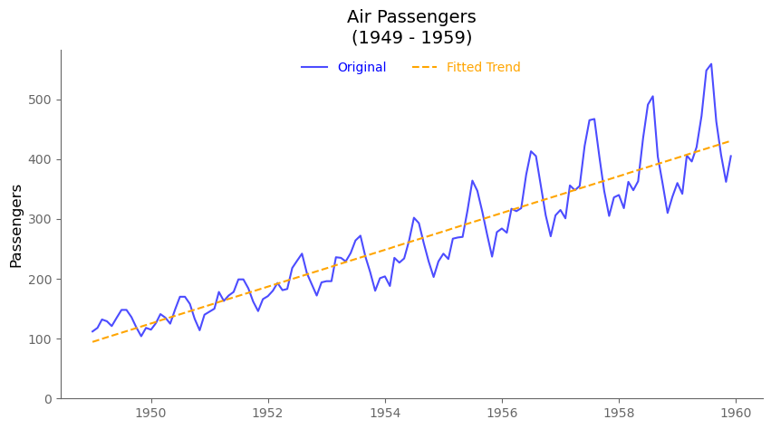

```python
def org_series():
    '''This function shows the original series with a fitted trend
    '''

    plt.figure(figsize=(10, 5))

    # Plot the original time series data
    ax = sns.lineplot(data  = df_his['#Passengers'],
                      label ='Original',
                      color = 'blue',
                      alpha = 0.7)

    # Plot the trend linear lin  Fit a linear trend line
    m, b2 = np.polyfit(df_his['time period'],
                       df_his['#Passengers'], 1)  #linear fit

    trend_line = m * df_his['time period'] + b2  # Calculate the trend line values
    plt.plot(trend_line,
             '--',
             label = 'Fitted Trend',
             color = 'orange')

    plt.ylim(bottom = 0)
    # Show the plot
    plot_props(title    = 'Air Passengers\n(1949 - 1959)',
                y_label = 'Passengers',
                lgn_loc = 'upper center',
                lgn_col = 2)

org_series()
```

**Augmented Dickey-Fuller (ADF) Test for Trend:**

```python
adf_result = adfuller(df_his["#Passengers"])
print(f'ADF Statistic: {adf_result[0]}')
print(f'p-value: {adf_result[1]}')

if adf_result[1] < 0.05:
    print("The time series is stationary (No trend).")
else:
    print("The time series is non-stationary (Likely a trend).")
```

```
ADF Statistic: 0.8880265130075043
p-value: 0.9929320626482829
The time series is non-stationary (Likely a trend).
```

**Conclusions:**

- **Trend:** According to Graph with fitted trend line, the number of passengers have a `Upward Trend`; over time, the number of passengers tends to increase with new higest value every year.
- **Seasonality:** There are seasonal factors in the data and can be observed in the Original Series Graph above

### 2. How many seasons can be recognised in this data set?

There are `12` seasons, as according tho the graph in Question 1 monthly air passengers typically follow an annual cycle where patterns repeat every `12 months`. So, the seasonality period is `12 months`, meaning one full cycle patterns repeat every year.

The result of the Autocorrelation Function method below also confirms this.

```python
# Compute autocorrelation
autocorr = np.correlate(df_his['#Passengers'] - df_his['#Passengers'].mean(),
                        df_his['#Passengers'] - df_his['#Passengers'].mean(),
                        mode = 'same')
autocorr = autocorr[len(autocorr)//2:]  # Take only positive lags

# Find peaks in autocorrelation
peaks, _ = find_peaks(autocorr, height=0)
seasonality_period = peaks[0]  # First significant peak

print(f"Detected seasonality period: {seasonality_period}")
```

```
Detected seasonality period: 12
```

### 3. Calculate appropriate moving averages for this `11-year` data set (`1949 - 1959`) to smooth out the trend. Then calculate the seasonal components values. Provide an interpretation for the seasonal factor values.

#### The `16-month` Centered Moving Average (CMA) for `11 years` data (`1949-1959`):

With `11-year` monthly data, the window of the CMA should be large enough to smoothly capture the trend but small enough to keep the details for optimal prediction later.

After trying different window values for the `CMA`, `16` seems to be an appropriate value. Which results in minimal fitting and testing errors.

```python
# Calculate the centered moving average with a window of 16
ma = 16
df_his['MA'] = df_his['#Passengers'].rolling(window = ma, center = True).mean()
df_his['CMA'] = df_his['MA'].rolling(window = 2, center=True).mean()

# Calculate the Seasonal factors
df_his['s'] = df_his['#Passengers'] / df_his['CMA']
```

```python
# show the first 20 rows of calculated CMA and seaonsal factors
df_his.head(20)
```

| month | Month | time period | #Passengers | MA | CMA | s |
| --- | --- | --- | --- | --- | --- | --- |
| 1949-01-01 | 1949-01 | 1 | 112 | NaN | NaN | NaN |
| 1949-02-01 | 1949-02 | 2 | 118 | NaN | NaN | NaN |
| 1949-03-01 | 1949-03 | 3 | 132 | NaN | NaN | NaN |
| 1949-04-01 | 1949-04 | 4 | 129 | NaN | NaN | NaN |
| 1949-05-01 | 1949-05 | 5 | 121 | NaN | NaN | NaN |
| 1949-06-01 | 1949-06 | 6 | 135 | NaN | NaN | NaN |
| 1949-07-01 | 1949-07 | 7 | 148 | NaN | NaN | NaN |
| 1949-08-01 | 1949-08 | 8 | 148 | NaN | NaN | NaN |
| 1949-09-01 | 1949-09 | 9 | 136 | 127.3125 | NaN | NaN |
| 1949-10-01 | 1949-10 | 10 | 119 | 128.1250 | 127.71875 | 0.931735 |
| 1949-11-01 | 1949-11 | 11 | 104 | 130.0625 | 129.09375 | 0.805616 |
| 1949-12-01 | 1949-12 | 12 | 118 | 132.4375 | 131.25000 | 0.899048 |
| 1950-01-01 | 1950-01 | 13 | 115 | 135.0000 | 133.71875 | 0.860014 |
| 1950-02-01 | 1950-02 | 14 | 126 | 137.3125 | 136.15625 | 0.925407 |
| 1950-03-01 | 1950-03 | 15 | 141 | 137.1875 | 137.25000 | 1.027322 |
| 1950-04-01 | 1950-04 | 16 | 135 | 135.0625 | 136.12500 | 0.991736 |
| 1950-05-01 | 1950-05 | 17 | 125 | 134.5625 | 134.81250 | 0.927214 |
| 1950-06-01 | 1950-06 | 18 | 149 | 135.1250 | 134.84375 | 1.104983 |
| 1950-07-01 | 1950-07 | 19 | 170 | 137.0625 | 136.09375 | 1.249139 |
| 1950-08-01 | 1950-08 | 20 | 170 | 141.6875 | 139.37500 | 1.219731 |

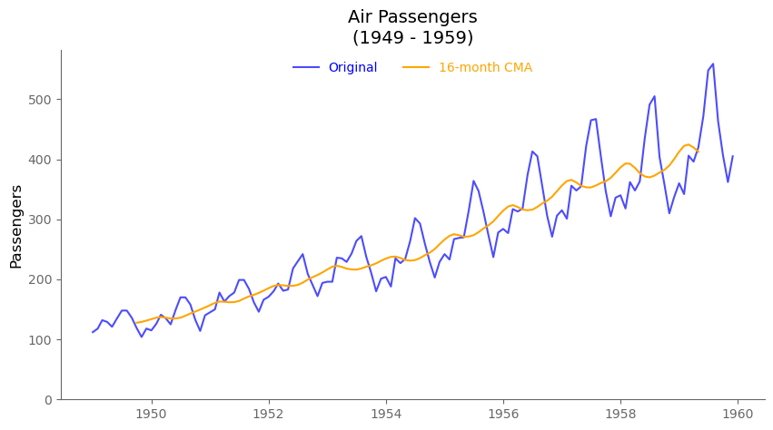

```python
plt.figure(figsize=(10, 5))

# Plot the original time series data
sns.lineplot(df_his['#Passengers'],
             label ='Original',
             color = 'blue',
             alpha = 0.7)

# Plot the moving average trend line
sns.lineplot(df_his['CMA'],
             label ='16-month CMA',
             color = 'orange')

plt.ylim(bottom = 0)
# Show the plot
plot_props(title   = 'Air Passengers\n(1949 - 1959)',
           y_label = 'Passengers',
           lgn_loc = 'upper center',
           lgn_col = 2)
```

#### Calculating Seasonal Components Values:

##### 1. Typical Seasonal Factors:

For the `Multiplicative Time Series Model`:

$$\text{Number of Passengers} = \text{Trend} \times \text{Seasonal}$$

With:

- `Seasonal` is the *Typical Seasonal Factors* of each month:

$$\text{Seasonal} = \text{Correction Factor} \times \text{Average Seasonal Values}$$$$\text{Correction Factor} = \frac{ \text{Number of Seasons}}{\sum \text{Average Seasonal Factors}}$$

```python
# Typical seasonal factor calculation
df_his['calendar_month'] = df_his.index.astype(str).str[-5:-3] # extract the month value
df_60['calendar_month'] = df_60.index.astype(str).str[-5:-3] # extract the month value
avg_seasonal = df_his.groupby('calendar_month')['s'].mean() # monthly seasonal factor averages
avg_seasonal = avg_seasonal.to_frame()
avg_seasonal.rename(columns={'s':'s_mean'}, inplace = True)

# correction factor
correct_ft = 12/sum(avg_seasonal['s_mean'])

# Calculate Typical seasonal factors
avg_seasonal['typ_S'] = avg_seasonal['s_mean'] * correct_ft

avg_seasonal
```

| calendar_month | s_mean | typ_S |
| --- | --- | --- |
| 01 | 0.892995 | 0.883641 |
| 02 | 0.865358 | 0.856293 |
| 03 | 0.998255 | 0.987798 |
| 04 | 0.974339 | 0.964133 |
| 05 | 0.999732 | 0.989260 |
| 06 | 1.148203 | 1.136176 |
| 07 | 1.274831 | 1.261478 |
| 08 | 1.257137 | 1.243968 |
| 09 | 1.082897 | 1.071554 |
| 10 | 0.935604 | 0.925804 |
| 11 | 0.804855 | 0.796424 |
| 12 | 0.892824 | 0.883472 |

##### 2. Deseasonalised Values:

With *Deseasonalised Passengers*: $$\text{Deseasonalised Passengers} = \frac{\text{Number of Passengers}}{\text{Typical Seasonal Factors}}$$

```python
# join the avg_seasonal and df_his dataframes
df_his = pd.merge(df_his, avg_seasonal,
              on='calendar_month',
              how='left') #Left Join
df_his = df_his.drop(columns = 's_mean')

# deseasonalise
df_his['deseason_passengers'] = df_his['#Passengers'] / df_his['typ_S']

# join the avg_seasonal and df_60 dataframes
df_60 = pd.merge(df_60, avg_seasonal,
              on='calendar_month',
              how='left') #Left Join
```

### 4. Which model describes this data set the best – additive or multiplicative? Why?

Based on the graph shown in Question 1, the **Multiplicative Model** is appropriate to be used for the Forecasting Model. Because the variations show a proportional swift around the trend line.

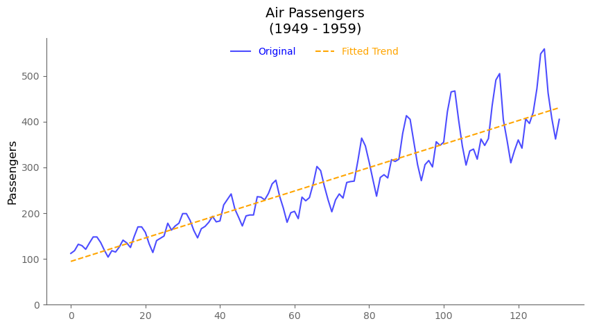

```python
# Show the Original Series Plot again
org_series()
```

### 5. Forecast the number of Airline passengers for the last year (`1960`) according to the data of previous years (`1949 - 1959`).

```python
# casting the dataset indices as timestamp type
df_his['month'] = pd.to_datetime(df_his['Month'], format='%Y-%m')
df_his.set_index('month', inplace=True)
df_his = df_his.drop(columns = ['calendar_month', 'Month'])

df_60['month'] = pd.to_datetime(df_60['Month'], format='%Y-%m')
df_60.set_index('month', inplace=True)
df_60 = df_60.drop(columns = ['calendar_month', 'Month'])
```

#### Linearly Fit the Deseasoned Trend:

```python
# slope and intercept of the times series prediction
a, b = np.polyfit(df_his['time period'], df_his['deseason_passengers'], 1)  # 1 means linear fit
```

#### Forecast the Number of Passengers:

```python
# predict deseasonalised
df_his['pred_deseason'] = a * df_his['time period'] + b # fitted data on the hitorical set
df_60['pred_deseason'] = a * df_60['time period'] + b  # 1960 predictions

# predict #Passengers
df_his['pred_passengers'] = df_his['pred_deseason'] * df_his['typ_S'] # fitted data on the hitorical set
df_60['pred_passengers'] = df_60['pred_deseason'] * df_60['typ_S'] # 1960 predictions
```

```python
# Show the 1960 Dataset (#Passengers: Actual; pred_passengers: Prediction)
df_60
```

| month | time period | #Passengers | s_mean | typ_S | pred_deseason | pred_passengers |
| --- | --- | --- | --- | --- | --- | --- |
| 1960-01-01 | 133 | 417 | 0.892995 | 0.883641 | 432.466857 | 382.145422 |
| 1960-02-01 | 134 | 391 | 0.865358 | 0.856293 | 435.017345 | 372.502412 |
| 1960-03-01 | 135 | 419 | 0.998255 | 0.987798 | 437.567833 | 432.228576 |
| 1960-04-01 | 136 | 461 | 0.974339 | 0.964133 | 440.118321 | 424.332552 |
| 1960-05-01 | 137 | 472 | 0.999732 | 0.989260 | 442.668809 | 437.914458 |
| 1960-06-01 | 138 | 535 | 1.148203 | 1.136176 | 445.219297 | 505.847544 |
| 1960-07-01 | 139 | 622 | 1.274831 | 1.261478 | 447.769785 | 564.851593 |
| 1960-08-01 | 140 | 606 | 1.257137 | 1.243968 | 450.320273 | 560.184080 |
| 1960-09-01 | 141 | 508 | 1.082897 | 1.071554 | 452.870761 | 485.275332 |
| 1960-10-01 | 142 | 461 | 0.935604 | 0.925804 | 455.421249 | 421.630689 |
| 1960-11-01 | 143 | 390 | 0.804855 | 0.796424 | 457.971737 | 364.739737 |
| 1960-12-01 | 144 | 432 | 0.892824 | 0.883472 | 460.522224 | 406.858361 |

#### Fitted vs. Actual Data During `1949 - 1959`:

The decomposition model fit well with historical data, accurately capturing both the trend and seasonal fluctuations, providing reliable forecasts for future passenger numbers.

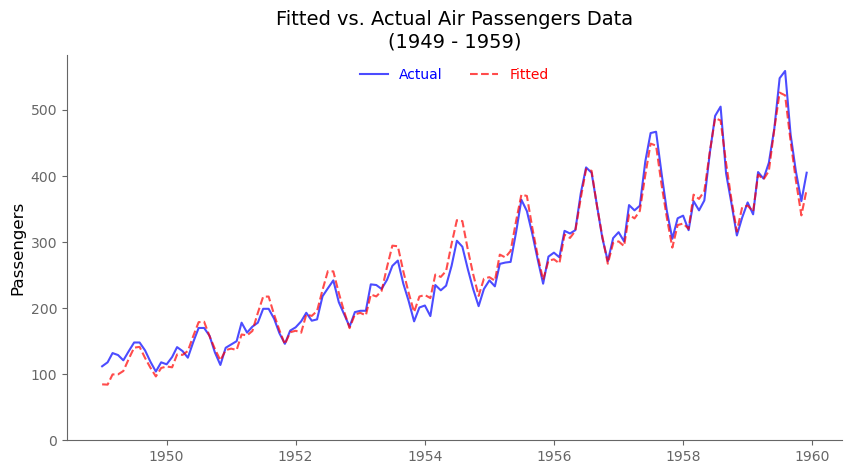

```python
plt.figure(figsize=(10, 5))

# Plot the actual series
sns.lineplot(x      = df_his.index,
             y      = df_his['#Passengers'],
             label  = 'Actual',
             color  = 'blue',
             alpha  = 0.7)

# Plot the fitted data prediction
sns.lineplot(x         = df_his.index,
             y         = df_his['pred_passengers'],
             label     ='Fitted',
             color     = 'red',
             alpha     = 0.7,
             linestyle = 'dashed')

plt.ylim(bottom = 0)
# Show the plot
plot_props(title   = 'Fitted vs. Actual Air Passengers Data\n(1949 - 1959)',
           y_label = 'Passengers',
           lgn_loc = 'upper center',
           lgn_col = 2)
```

#### Air Passengers during `1949 - 1959` and its `1960` Prediction:

Air passenger numbers are predicted to continue following the rising trend, with seasonal fluctuations remaining consistent.

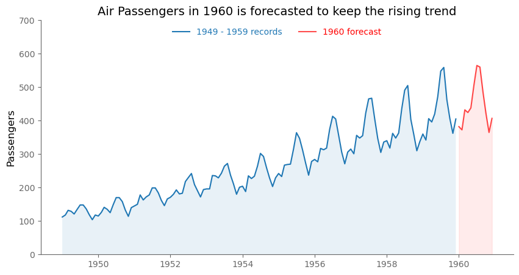

```python
plt.figure(figsize=(10, 5))

# Plot the first 11 years  of time series data
sns.lineplot(x      = df_his.index,
             y      = df_his['#Passengers'],
             label  = '1949 - 1959 records')

# predicted data in 1960 with the last month data of 1959 for continuous visualisation only


# Plot the 1960 prediction
sns.lineplot(x       = df_60.index,
             y       = df_60['pred_passengers'],
             label   = '1960 forecast',
             color   = 'red',
             alpha   = 0.7)

# Fill under the curve
plt.fill_between(df_his.index, df_his['#Passengers'], alpha=.1)
plt.fill_between(df_60.index, df_60['pred_passengers'], color = 'red', alpha=.08)

plt.ylim(0, 700)
# Show the plot
plot_props(title   = 'Air Passengers in 1960 is forecasted to keep the rising trend',
           y_label = 'Passengers',
           lgn_loc = 'upper center',
           lgn_col =  2)
```

#### Predicted vs. Actual Passengers Number in `1960`:

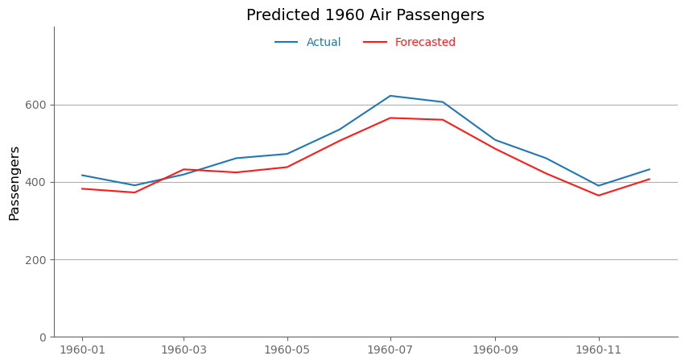

```python
plt.figure(figsize=(10, 5))

# Plot the first 11 years  of time series data
actual = df.loc['1960-01-01':'1960-12-31']
sns.lineplot(x       = actual.index,
             y       = actual['#Passengers'],
             label   ='Actual')

# Plot the 1960 prediction
sns.lineplot(x      = df_60.index,
             y      = df_60['pred_passengers'],
             label  ='Forecasted',
             color  = '#ff1a1a')  # Plot the trend line

plt.yticks([0, 200, 400, 600])
plt.ylim(0, 800)
plt.grid(axis = 'y')
# Show the plot
plot_props(title   = 'Predicted 1960 Air Passengers',
           y_label = 'Passengers',
           lgn_loc = 'upper center',
           lgn_col = 2)
```

### 6. Calculate the **Mean Absolute Error** and **Mean Square Error** for the forecasts.

- The fitted decomposition is fitted well with the historical data (`1949 - 1959`), with low Mean Absolute Error (`12.29`) and low Mean Squared Error (`223.59`). This means that the decomposition model generalises the historical data well.
- Regarding the `1960` prediction: On average, the prediction misses the actual number of 1960 passengers by about `31.8`. This means that, in absolute terms, the forecasted values are typically off by around `32` passengers.
- The MSE (`1149.1`) is sensitive to larger errors, meaning there were likely some larger errors in specific months. After testing the prediction with different CMA windows, the value of `16` resulted in the lowest possible MAE and MSE combination for the `1960` prediction.
- The higher errors in the `1960` predictions might due to other factors beyond the scope of the prediction using historical data, such as economic dynamic, market trend, etc.

```python
# error calculation
df_his['err'] = df_his['#Passengers'] - df_his['pred_passengers']
df_60['err'] = df_60['#Passengers'] - df_60['pred_passengers']

# absolute error
df_his['abs_err'] = abs(df_his['#Passengers'] - df_his['pred_passengers'])
df_60['abs_err'] = abs(df_60['#Passengers'] - df_60['pred_passengers'])

# square error
df_his['sq_err'] = (df_his['err']) ** 2
df_60['sq_err'] = (df_60['err']) ** 2
```

```python
# Show the 1960 Data
df_60
```

| month | time period | #Passengers | s_mean | typ_S | pred_deseason | pred_passengers | err | abs_err | sq_err |
| --- | --- | --- | --- | --- | --- | --- | --- | --- | --- |
| 1960-01-01 | 133 | 417 | 0.892995 | 0.883641 | 432.466857 | 382.145422 | 34.854578 | 34.854578 | 1214.841584 |
| 1960-02-01 | 134 | 391 | 0.865358 | 0.856293 | 435.017345 | 372.502412 | 18.497588 | 18.497588 | 342.160758 |
| 1960-03-01 | 135 | 419 | 0.998255 | 0.987798 | 437.567833 | 432.228576 | -13.228576 | 13.228576 | 174.995210 |
| 1960-04-01 | 136 | 461 | 0.974339 | 0.964133 | 440.118321 | 424.332552 | 36.667448 | 36.667448 | 1344.501735 |
| 1960-05-01 | 137 | 472 | 0.999732 | 0.989260 | 442.668809 | 437.914458 | 34.085542 | 34.085542 | 1161.824194 |
| 1960-06-01 | 138 | 535 | 1.148203 | 1.136176 | 445.219297 | 505.847544 | 29.152456 | 29.152456 | 849.865718 |
| 1960-07-01 | 139 | 622 | 1.274831 | 1.261478 | 447.769785 | 564.851593 | 57.148407 | 57.148407 | 3265.940470 |
| 1960-08-01 | 140 | 606 | 1.257137 | 1.243968 | 450.320273 | 560.184080 | 45.815920 | 45.815920 | 2099.098565 |
| 1960-09-01 | 141 | 508 | 1.082897 | 1.071554 | 452.870761 | 485.275332 | 22.724668 | 22.724668 | 516.410545 |
| 1960-10-01 | 142 | 461 | 0.935604 | 0.925804 | 455.421249 | 421.630689 | 39.369311 | 39.369311 | 1549.942647 |
| 1960-11-01 | 143 | 390 | 0.804855 | 0.796424 | 457.971737 | 364.739737 | 25.260263 | 25.260263 | 638.080863 |
| 1960-12-01 | 144 | 432 | 0.892824 | 0.883472 | 460.522224 | 406.858361 | 25.141639 | 25.141639 | 632.102027 |

```python
# Mean Absolute Error (MAE) and Mean Squared Error (MSE) in both historical and 1960 predictions

# Historical Data
mae_his = df_his['abs_err'].mean() # MAE
mse_his = df_his['sq_err'].mean() # MSE
print(f'- Mean Absolute Error (MAE) of Passengers Historical Prediction: {mae_his}')
print(f'- Mean Squared Error (MSE) of Passengers Historical Prediction: {mse_his}\n')

# 1960 Predictions
mae = df_60['abs_err'].mean() # MAE
mse = df_60['sq_err'].mean() # MSE
print(f'- Mean Absolute Error (MAE) of Passengers Prediction in 1960: {mae}')
print(f'- Mean Squared Error (MSE) of Passengers Prediction in 1960: {mse}')
```

```
- Mean Absolute Error (MAE) of Passengers Historical Prediction: 12.29439952661986
- Mean Squared Error (MSE) of Passengers Historical Prediction: 223.5907024351952

- Mean Absolute Error (MAE) of Passengers Prediction in 1960: 31.82886638237167
- Mean Squared Error (MSE) of Passengers Prediction in 1960: 1149.1470262660423
```